# IMT 573: Problem Set 1 - Exploring Data

KULRAJ SINGH KOHLI

Due: October 13 2019

## Instructions

Before beginning this assignment, please ensure you have access to R and RStudio.

1. Replace the “Insert Your Name Here” text in the `author:` FIeld with your own full name.
2. Be sure to include well-documented (e.g. commented) code chucks, FIgures and clearly written text chunk explanations as necessary. Any FIgures should be clearly labeled and appropriately referenced within the text.
3. When you have completed the assignment and have **checked** that your code both runs in the Console and knits correctly when you click `Knit PDF`, rename the R Markdown FIle to `YourLastName-YourFIrstName-ps1.Rmd`, knit a PDF and submit the PDF FIle on Canvas.
4. List any collaborators below:

### Collaborators:

Harpreet

## Setup:

loading libraries

```r
# Load standard libraries
library("tidyverse")
library("nycflights13")
data(flights)
```

## Problem 1: Exploring the NYC Flights Data

### (a) Importing and Inspecting Data:

IMPORTING DATA ON ALL FLIGHTS THAT DEPARTED NYC IN 2013 FROM THE PACKAGE nycflights13

```r
# loading nyc flights library and seleting the table flights
library("nycflights13")
data(flights)
# summary of flights table
summary(flights)
```

```
##       year          month             day           dep_time
##  Min.   :2013   Min.   : 1.000   Min.   : 1.00   Min.   :   1
##  1st Qu.:2013   1st Qu.: 4.000   1st Qu.: 8.00   1st Qu.: 907
##  Median :2013   Median : 7.000   Median :16.00   Median :1401
##  Mean   :2013   Mean   : 6.549   Mean   :15.71   Mean   :1349
##  3rd Qu.:2013   3rd Qu.:10.000   3rd Qu.:23.00   3rd Qu.:1744
##  Max.   :2013   Max.   :12.000   Max.   :31.00   Max.   :2400
##                                                  NA's   :8255
##  sched_dep_time   dep_delay          arr_time    sched_arr_time
##  Min.   : 106   Min.   : -43.00   Min.   :   1   Min.   :   1
##  1st Qu.: 906   1st Qu.:  -5.00   1st Qu.:1104   1st Qu.:1124
##  Median :1359   Median :  -2.00   Median :1535   Median :1556
##  Mean   :1344   Mean   :  12.64   Mean   :1502   Mean   :1536
##  3rd Qu.:1729   3rd Qu.:  11.00   3rd Qu.:1940   3rd Qu.:1945
##  Max.   :2359   Max.   :1301.00   Max.   :2400   Max.   :2359
##                 NA's   :8255      NA's   :8713
##    arr_delay          carrier              flight       tailnum
##  Min.   : -86.000   Length:336776      Min.   :   1   Length:336776
##  1st Qu.: -17.000   Class :character   1st Qu.: 553   Class :character
##  Median :  -5.000   Mode  :character   Median :1496   Mode  :character
##  Mean   :   6.895                      Mean   :1972
##  3rd Qu.:  14.000                      3rd Qu.:3465
##  Max.   :1272.000                      Max.   :8500
##  NA's   :9430
##     origin              dest              air_time        distance
##  Length:336776      Length:336776      Min.   : 20.0   Min.   :  17
##  Class :character   Class :character   1st Qu.: 82.0   1st Qu.: 502
##  Mode  :character   Mode  :character   Median :129.0   Median : 872
##                                        Mean   :150.7   Mean   :1040
##                                        3rd Qu.:192.0   3rd Qu.:1389
##                                        Max.   :695.0   Max.   :4983
##                                        NA's   :9430
##       hour           minute        time_hour
##  Min.   : 1.00   Min.   : 0.00   Min.   :2013-01-01 05:00:00
##  1st Qu.: 9.00   1st Qu.: 8.00   1st Qu.:2013-04-04 13:00:00
##  Median :13.00   Median :29.00   Median :2013-07-03 10:00:00
##  Mean   :13.18   Mean   :26.23   Mean   :2013-07-03 05:22:54
##  3rd Qu.:17.00   3rd Qu.:44.00   3rd Qu.:2013-10-01 07:00:00
##  Max.   :23.00   Max.   :59.00   Max.   :2013-12-31 23:00:00
##
```

```r
# looking for datatypes and dimensions
str(flights)
```

```
## Classes 'tbl_df', 'tbl' and 'data.frame':    336776 obs. of  19 variables:
##  $ year          : int  2013 2013 2013 2013 2013 2013 2013 2013 2013 2013 ...
##  $ month         : int  1 1 1 1 1 1 1 1 1 1 ...
##  $ day           : int  1 1 1 1 1 1 1 1 1 1 ...
##  $ dep_time      : int  517 533 542 544 554 554 555 557 557 558 ...
##  $ sched_dep_time: int  515 529 540 545 600 558 600 600 600 600 ...
##  $ dep_delay     : num  2 4 2 -1 -6 -4 -5 -3 -3 -2 ...
##  $ arr_time      : int  830 850 923 1004 812 740 913 709 838 753 ...
##  $ sched_arr_time: int  819 830 850 1022 837 728 854 723 846 745 ...
##  $ arr_delay     : num  11 20 33 -18 -25 12 19 -14 -8 8 ...
##  $ carrier       : chr  "UA" "UA" "AA" "B6" ...
##  $ flight        : int  1545 1714 1141 725 461 1696 507 5708 79 301 ...
##  $ tailnum       : chr  "N14228" "N24211" "N619AA" "N804JB" ...
##  $ origin        : chr  "EWR" "LGA" "JFK" "JFK" ...
##  $ dest          : chr  "IAH" "IAH" "MIA" "BQN" ...
##  $ air_time      : num  227 227 160 183 116 150 158 53 140 138 ...
##  $ distance      : num  1400 1416 1089 1576 762 ...
##  $ hour          : num  5 5 5 5 6 5 6 6 6 6 ...
##  $ minute        : num  15 29 40 45 0 58 0 0 0 0 ...
##  $ time_hour     : POSIXct, format: "2013-01-01 05:00:00" "2013-01-01 05:00:00" ...
```

## (a) Importing and Inspecting Data

Load the data and describe in a short paragraph how the data was collected and what each variable represents. Perform a basic inspection of the data and discuss what you FInd.

The package, “nycflights13” contains information about all the flights from NYC to other destinations in the USA in the year 2013. It contains a total of 336,776 flights and the dataset also has a lot of variables which might help us understand the reason for delays. This data has been collected by RITA, Bureau of transportation statistics which has been reporting carrier on-time performance since 1987. We use the str(flights) function to look at the dataypes and the structure of the dataframe. There are 19 variables in the dataset: 1. year (int) - Represents the year i.e. 2013 from where this data about all the flights departing NYC to other destinations in the U.S was collected. 2. month (int) - Represents the month of the flight departures. 3. day (int) - Represents what day of the month the flight was scheduled. It is an integer datatype. 4. dep_time (int) - Actual departure times (format HHMM or HMM) in its local timezone (tz). 5.arr_time (int) - Actual departure times (format HHMM or HMM) in its local tz. 6. sched_dep_time (int) - Scheduled departure times (format HHMM or HMM), local tz. 7. sched_arr_time (int) - Scheduled arrival times (format HHMM or HMM), local tz. 8. dep_delay (double) - Departure delays, in minutes. Negative times represent early departures/arrivals. 9. arr_delay (double) - Arrival delays, in minutes. Negative times represent early departures/arrivals. 10. carrier (character) - Two letter carrier abbreviation. See airlines to get name. 11. flight (int) - Flight number. 12. tailnum (character) - Plane tail number. See planes for additional metadata. 13. origin (character) - Origin of the flight. 14. dest (character) - destination of the flight. 15. distance (double) - Distance between airports, in miles. 16. hour (double) - Time of 3 scheduled departure broken into hour. 17. minute (double)- Time of scheduled departure broken minutes. 18. time_hour - Scheduled date and hour of the flight as a POSIXct date. 19. air_time (double) - Amount of time spent in the air, in minutes.

### (b) Formulating Questions:

Consider the NYC flights data. Formulate two motivating questions you want to explore using this data. Describe why these questions are interesting and how you might go about answering them.

1. The FIrst thing I want to know is whether the delayed flights are carrier speciFIc. That is, is a certain airlines more notorious for causing delayed flights.
2. The second question that really intrigued me is whether a speciFIc destination airport is causing delays for the flights.

### (c) Exploring Data:

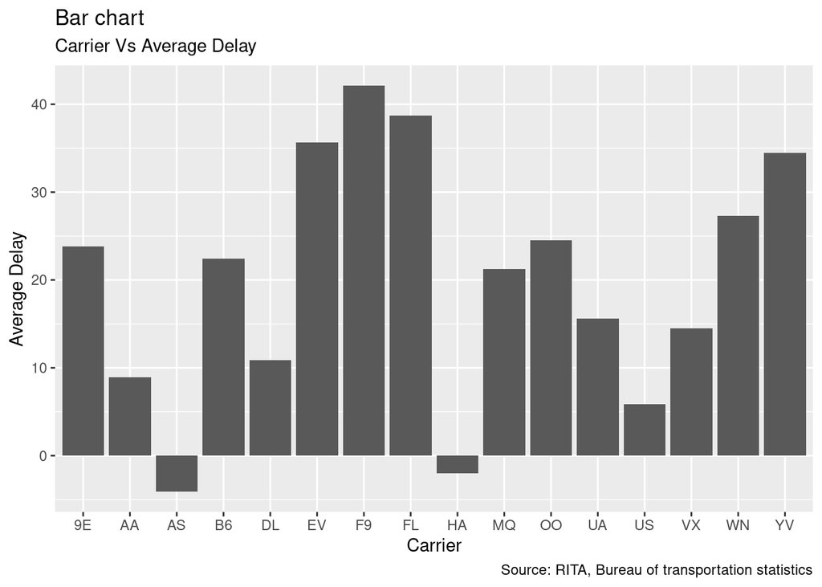

```r
flights %>%
group_by(carrier) %>%
summarise(average_delay = mean(dep_delay + arr_delay, na.rm = TRUE)) %>%
ggplot(aes(carrier, average_delay)) + geom_bar(stat = 'identity',FIll='blue') +
labs(subtitle="Carrier Vs Average Delay",
y="Average Delay",
x="Carrier",
title="Bar chart",
caption = "Source: RITA, Bureau of transportation statistics")
```

Here, the total delay times for speciFIc airlines are displayed. The total departure and arrival delays were added to calculate the total delay. The average total delay was then calculated using the mean() and summarize() function. These delay times were grouped by various carriers to display the aveage delay times for all the carriers using a histogram.

We learn here that the F9 airlines is most notorious for causing delays and AS gets you to your destination quicker than you want

#### Now, we calculate the same for only the flights that were delayed during departure.

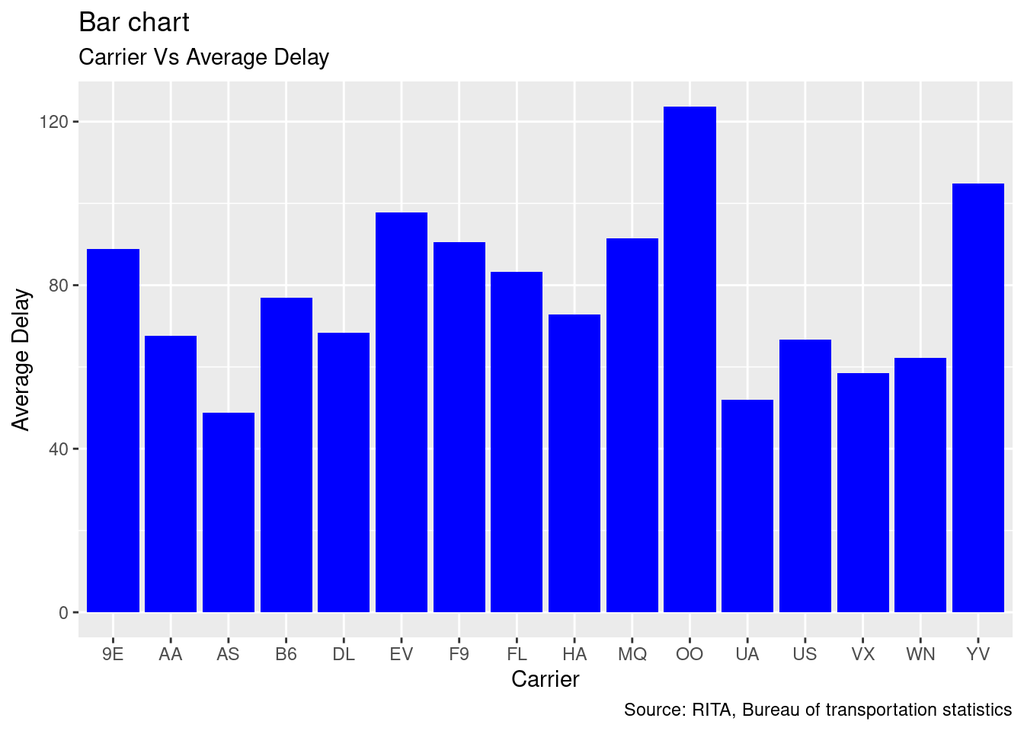

```r
flights %>%
group_by(carrier) %>%
# we FIlter out the flights that were delayed during departure
filter(dep_delay>0) %>%
summarise(average_delay = mean(dep_delay + arr_delay, na.rm = TRUE)) %>%
ggplot(aes(carrier, average_delay)) + geom_bar(stat = 'identity',fill='blue') +
labs(subtitle="Carrier Vs Average Delay",
y="Average Delay",
x="Carrier",
title="Bar chart",
caption = "Source: RITA, Bureau of transportation statistics")
```

If your flight is delayed during departure it is most likely that OO will take the longest time to the dest and AS will minimize the delay to the maximum.

## Second question

```r
# FIltering null enteries
fullflight <- flights[complete.cases(flights),]
#create a column for whether the flight is delayed or not(more than 2 min)
dests <- fullflight %>% mutate(delayed1 = ifelse(dep_delay>2,"delayed","on-time"))
dests
```

| year | month | day | dep_time | sched_dep_time | dep_delay | arr_time | sched_arr_time | arr_delay | carrier | flight | tailnum | origin | dest | air_time | distance | hour | minute | time_hour | delayed1 |
| --- | --- | --- | --- | --- | --- | --- | --- | --- | --- | --- | --- | --- | --- | --- | --- | --- | --- | --- | --- |
| 2013 | 1 | 1 | 517 | 515 | 2 | 830 | 819 | 11 | UA | 1545 | N14228 | EWR | IAH | 227 | 1400 | 5 | 15 | 2013-01-01 05:00:00 | on-time |
| 2013 | 1 | 1 | 533 | 529 | 4 | 850 | 830 | 20 | UA | 1714 | N24211 | LGA | IAH | 227 | 1416 | 5 | 29 | 2013-01-01 05:00:00 | delayed |
| 2013 | 1 | 1 | 542 | 540 | 2 | 923 | 850 | 33 | AA | 1141 | N619AA | JFK | MIA | 160 | 1089 | 5 | 40 | 2013-01-01 05:00:00 | on-time |
| 2013 | 1 | 1 | 544 | 545 | -1 | 1004 | 1022 | -18 | B6 | 725 | N804JB | JFK | BQN | 183 | 1576 | 5 | 45 | 2013-01-01 05:00:00 | on-time |
| 2013 | 1 | 1 | 554 | 600 | -6 | 812 | 837 | -25 | DL | 461 | N668DN | LGA | ATL | 116 | 762 | 6 | 0 | 2013-01-01 06:00:00 | on-time |
| 2013 | 1 | 1 | 554 | 558 | -4 | 740 | 728 | 12 | UA | 1696 | N39463 | EWR | ORD | 150 | 719 | 5 | 58 | 2013-01-01 05:00:00 | on-time |
| 2013 | 1 | 1 | 555 | 600 | -5 | 913 | 854 | 19 | B6 | 507 | N516JB | EWR | FLL | 158 | 1065 | 6 | 0 | 2013-01-01 06:00:00 | on-time |
| 2013 | 1 | 1 | 557 | 600 | -3 | 709 | 723 | -14 | EV | 5708 | N829AS | LGA | IAD | 53 | 229 | 6 | 0 | 2013-01-01 06:00:00 | on-time |
| 2013 | 1 | 1 | 557 | 600 | -3 | 838 | 846 | -8 | B6 | 79 | N593JB | JFK | MCO | 140 | 944 | 6 | 0 | 2013-01-01 06:00:00 | on-time |
| 2013 | 1 | 1 | 558 | 600 | -2 | 753 | 745 | 8 | AA | 301 | N3ALAA | LGA | ORD | 138 | 733 | 6 | 0 | 2013-01-01 06:00:00 | on-time |

[output cut: 9990 more lines]

```r
# calculating a ratio for delayed times

dests%>% group_by(dest) %>% summarise(dep_rate_late= sum(delayed1 =="delayed")/n()) %>% arrange(desc(dep_rate_late))
```

| dest | dep_rate_late |
| --- | --- |
| HDN | 0.6428571 |
| ANC | 0.6250000 |
| CAE | 0.6226415 |
| JAC | 0.6190476 |
| SBN | 0.6000000 |
| MTJ | 0.5714286 |
| OKC | 0.5650794 |
| TUL | 0.5544218 |
| SMF | 0.4964539 |
| MDW | 0.4792547 |

[output cut: 94 more lines]

```r
# choosing the top ten late airports to do our visualization

dests1 <- sample_n(dests,25)
```